# Assignment 01 - Introduction to the `spatstat` package

Dhun Sheth

08 April, 2024 14:05:12

Complete the following exercises and submit to Canvas before the due date In addition to the points detailed below, 5 points are assigned to the quality of the annotation and to the ‘cleanliness’ of the code and resulting pdf document.

## Exercise 1 – 5 points

- Import the BC park locations dataset. – 0.5 point(s)
- Identify the class of each element within the list. – 0.5 point(s)
- Visualise each element within the list using methods appropriate to each object class. – 1 point(s)
- Convert the data to a `ppp` object (be sure to include information on regions as marks). – 2 point(s)
- Run `plot()` on the resulting `ppp` object. – 0.5 point(s)
- Briefly describe the dataset. – 0.5 point(s)

Note: You will need to load the `sp` package and make use of the `as.owin()` function.

```r
library(spatstat) # loading spatstat library
```

### Loading Data

```r
load('BC_Parks.Rda')
library(viridis)
library(colorspace)
library(sf)
library(spatstat.geom)
```

### Identify class of each object within “DATA”

```r
class_type <- sapply(DATA, class)
print(class_type)
```

```
## $Parks
## [1] "data.frame"
##
## $Window
## [1] "sfc_MULTIPOLYGON" "sfc"
##
## $Elevation
## [1] "im"
```

### Visualizing each element in “DATA”

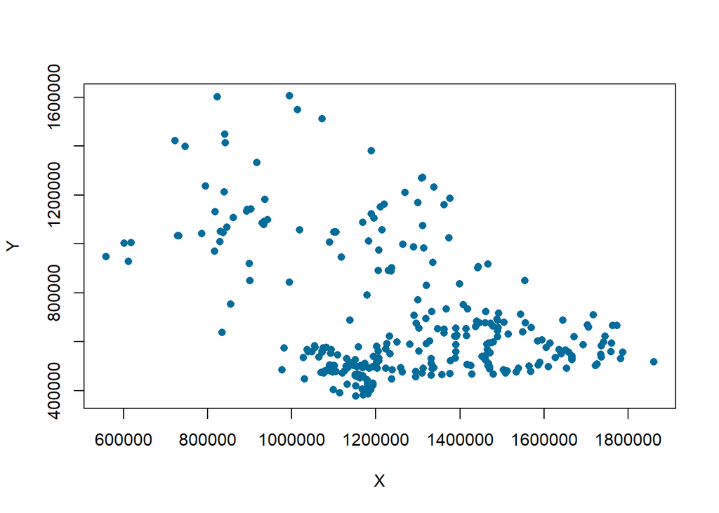

```r
# Parks
plot(Y ~ X,
     pch = 16,
     col = "#046C9A",
     data = DATA$Parks)
```

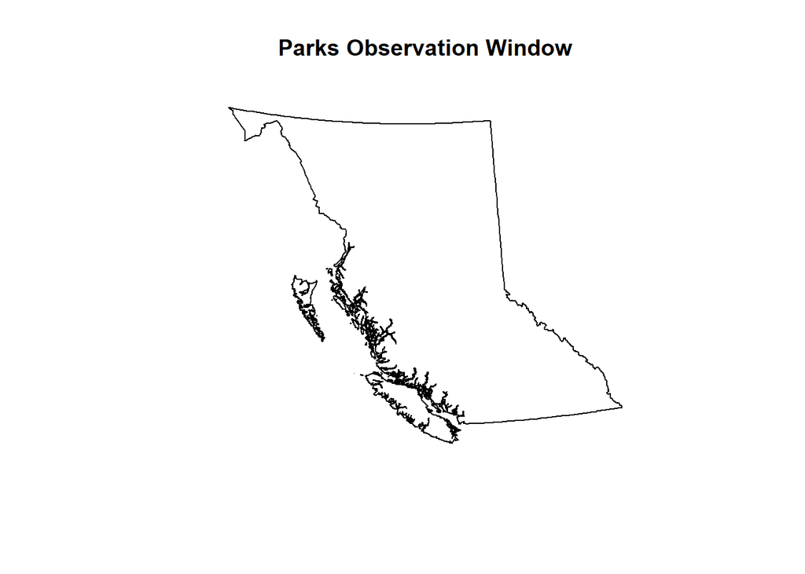

```r
# Window
parks_win <- as.owin(DATA$Window)
plot(parks_win, main = "Parks Observation Window")
```

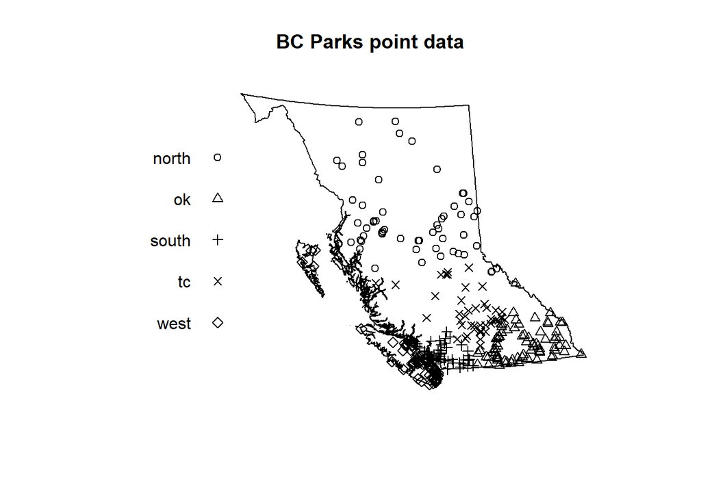

```r
# Converting data to ppp object
parks_ppp <- ppp(x = DATA$Parks$X, # X coordinates
                    y = DATA$Parks$Y, # Y coordinates
                    window = parks_win) # Observation window

#Visualise the dataset
marks(parks_ppp) <- data.frame(Group = DATA$Parks$Region,
                               Park_Name = DATA$Parks$Park)

plot(parks_ppp,
     which.marks = 'Group',
     main = "BC Parks point data")
```

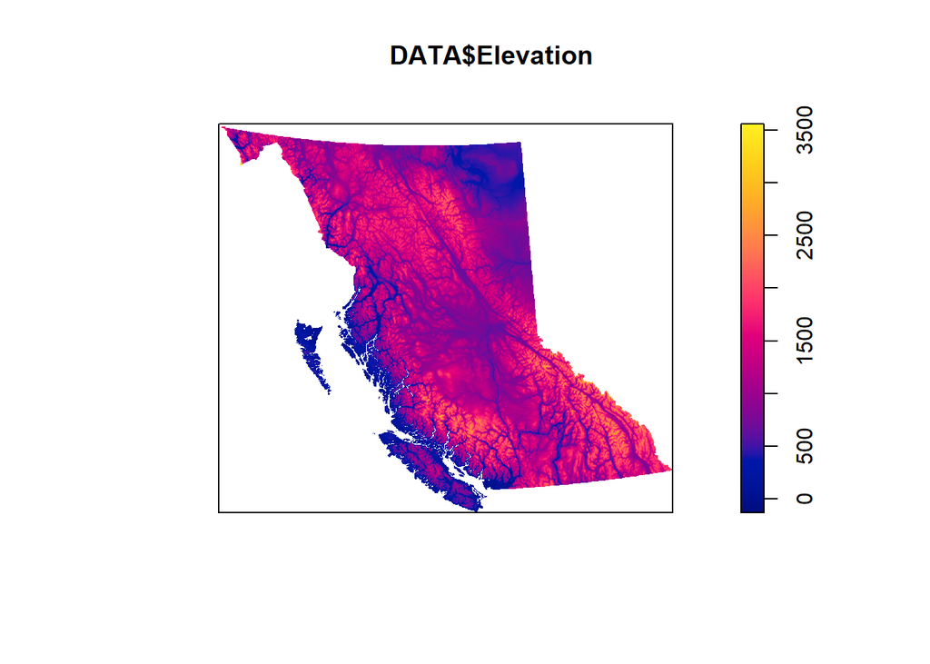

```r
# Elevation
plot(DATA$Elevation)
```

```r
# Describing the data
# summary(parks_ppp)
summary(as.data.frame(parks_ppp))
```

```
##        x                 y              Group            Park_Name
##  Min.   : 558510   Min.   : 377462   Length:289         Length:289
##  1st Qu.:1109149   1st Qu.: 497236   Class :character   Class :character
##  Median :1236731   Median : 576844   Mode  :character   Mode  :character
##  Mean   :1267654   Mean   : 686250
##  3rd Qu.:1461061   3rd Qu.: 830640
##  Max.   :1860321   Max.   :1604652
```

```r
# Number of points
npoints(parks_ppp)
```

```
## [1] 289
```

```r
#Coordinates and mark information
head(as.data.frame(parks_ppp))
```

|  | x | y | Group | Park_Name |
| --- | --- | --- | --- | --- |
| 1 | 1439472 | 682774.6 | tc | Adams Lake Park - Bush Creek Site |
| 2 | 1860321 | 517595.7 | ok | Akamina-Kishinena Park |
| 3 | 1331141 | 531785.5 | south | Alexandra Bridge Park |
| 4 | 1207526 | 534009.7 | south | Alice Lake Park |
| 5 | 1389223 | 533190.0 | ok | Allison Lake Park |
| 6 | 1314235 | 983697.1 | north | Ancient Forest/Chun T'oh Whudujut Park |

## Exercise 2 – 2 points

- Refine the figure of the point pattern. You must modify at least 5 graphical parameters. The marks need to be visually distinct. – 2 point(s)

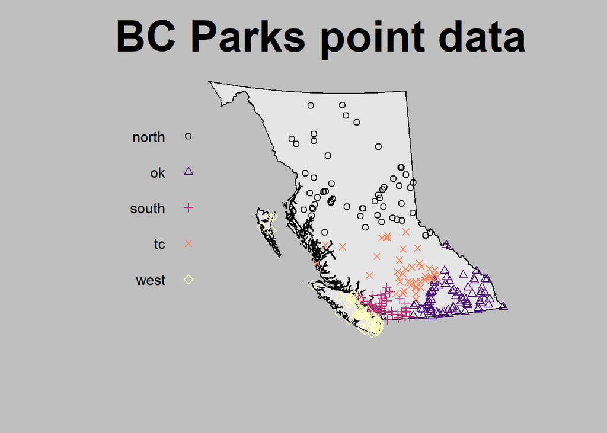

```r
# Adding discrete color pallet for each region
col_pal <- magma(length(unique(DATA$Parks$Region)))

plot(parks_ppp,
     which.marks = "Group",
     col = "grey90",
     cols = col_pal,
     par(bg="grey75", cex.main = 3),
     main = "BC Parks point data",
     legend=T)
```

## Exercise 3 – 5 points

- Create a perspective plot of the elevation image. You must modify at least 10 arguments of the `persp` function and can not use the `viridis()` colour pallet shown in the lab example. – 4 point(s)
- Overlay the park locations. – 1 point(s)

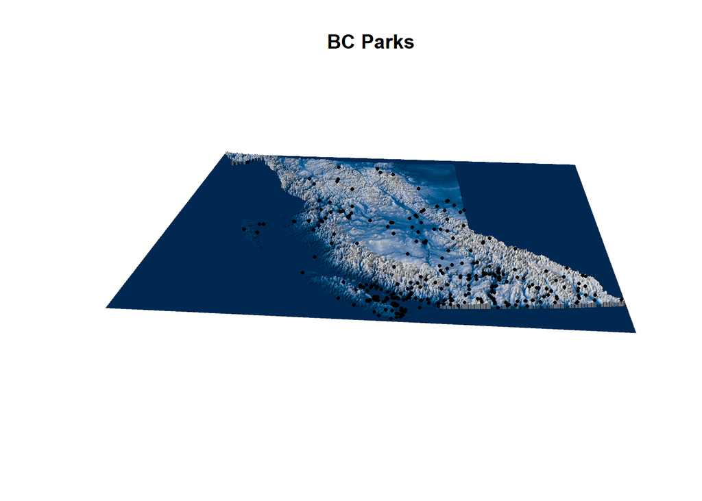

```r
pal <- sequential_hcl(100, "Blues 3") # Adding new color pallet for mapping

fig <- persp(DATA$Elevation, # source data
             theta = 5,
             phi = 25, # rotation
             expand = 9, # z-axis expansion
             border = NA, #remove grid borders
             apron = TRUE, #apron around edge
             shade = 0.4, # shading
             box = FALSE, # axes on/off
             main = "BC Parks", # title
             visible = TRUE, #Supporting calculations
             colmap = pal) # colour pallet

# Adding BC park locations to plot
perspPoints(DATA$Parks, Z = DATA$Elevation, M = fig, pch = 16, cex = 0.5)
```

## Exercise 4 – 2 points

- Split the elevation image into 5 elevation ‘classes’. – 0.5 point(s)
- Plot the elevation class image and overlay the park locations. – 0.5 point(s)
- Identify which of these elevation classes most parks fall in. – 1 point(s)

Note: The `table()` function is useful here.

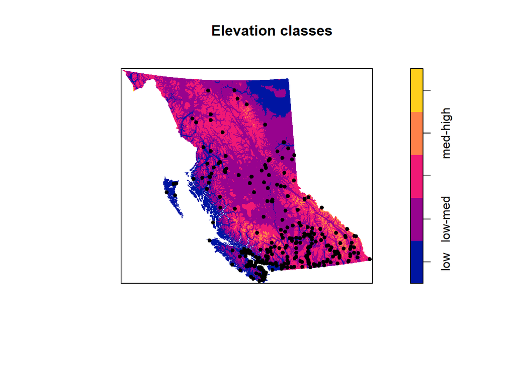

```r
# Plotting graph
elev_class <- cut(DATA$Elevation,
         5,
         labels = c("low","low-med", "medium", "med-high","high"))

plot(cut(DATA$Elevation,
         5,
         labels = c("low","low-med", "medium", "med-high","high")),
     main = "Elevation classes")

points(parks_ppp, pch = 20) # Adding park locations to graph
```

```r
# Identifying which class most parks fall under
table(elev_class[parks_ppp])
```

```
##
##      low  low-med   medium med-high     high
##      140      107       30        9        0
```

## Exercise 5 – 3 points

- Compute the distance from each park to its nearest neighbour. – 0.5 point(s)
- Mark the parks with this information. – 0.5 point(s)
- Plot the point pattern with information from these new marks. – 1 point(s)
- Identify the most isolated park in BC. – 1 point(s)

Note: The park names are stored in the `DATA` object.

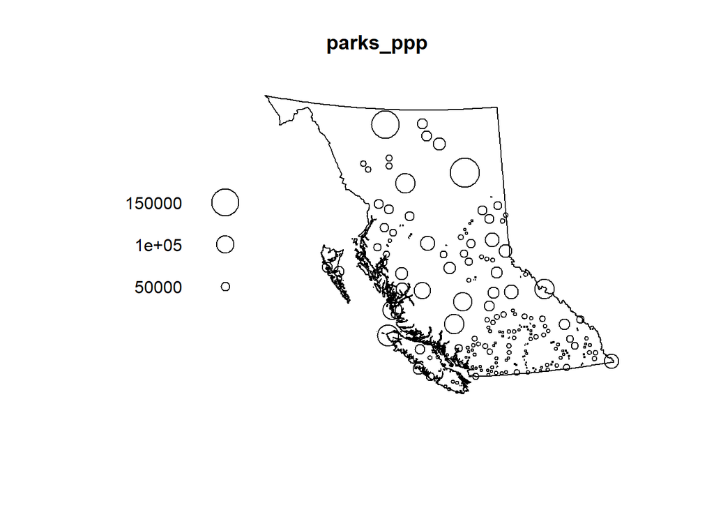

```r
m <- marks(parks_ppp) # Storing marks
m$Dist <- nndist(parks_ppp) # Adding nearest neighbor distance
marks(parks_ppp) <- m

plot(parks_ppp, which.marks = "Dist")
```

```r
print(m[which.max(m$Dist),]) # Identifying the most isolated park in BC
```

```
##    Group                       Park_Name   Dist
## 30 north Buckinghorse River Wayside Park 163884
```

Most isolated park in BC is Buckinghorse River Wayside Park.

## Exercise 6 – 3 points

- Calculate the median elevation within British Columbia and at park locations. – 1 point(s)
- Generate a kernel density estimate (KDE) of the distribution of elevation values within the province. – 0.5 point(s)
- Generate a KDE of the distribution of elevation values at park locations. – 0.5 point(s)
- Create a figure that overlays the two distributions. – 0.5 point(s)
- Include a legend. – 0.5 point(s)
- Do think that the spatial distribution of parks is random with respect to elevation? – 0.5 point(s)
- Identify both the highest and lowest elevation parks in BC. – 0.5 point(s)

Note: You may need to use the `density()`, `lines()`, and `legend()` functions.

```r
# Calculating Median elevation in BC and of BC parks
BC_median_elevation <- median(DATA$Elevation)
print(BC_median_elevation)
```

```
## [1] 1096.857
```

```r
BC_park_median_elevation <- median(DATA$Elevation[DATA$Parks])
print(BC_park_median_elevation)
```

```
## [1] 659.7841
```

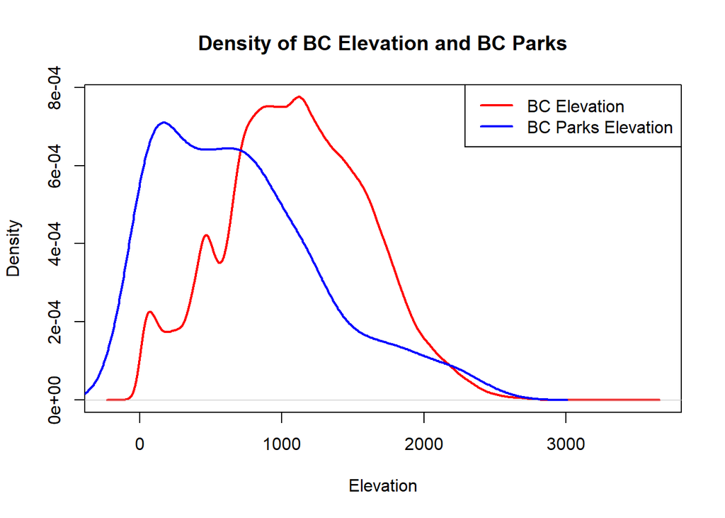

```r
# Generating KDE for elevation in BC and for elevation of BC parks
BC_elevation_density <- density(DATA$Elevation[])
BC_parks_elevation_density <- density(DATA$Elevation[DATA$Parks])

# Plotting density of elevation in BC
plot(BC_elevation_density, main = "Density of BC Elevation and BC Parks",
     xlab = "Elevation", ylab = "Density", col = "red", lwd = 2,
     ylim = range(c(BC_elevation_density$y, BC_parks_elevation_density$y)))

# Adding density of BC park elevations
lines(BC_parks_elevation_density, col = "blue", lwd = 2)

# Including legend
legend("topright", legend = c("BC Elevation", "BC Parks Elevation"),
       col = c("red", "blue"), lwd = 2)
```

```r
# Minimum elevation BC park
min_elevation_park <- DATA$Parks[which.min(DATA$Elevation[DATA$Parks]),]$Park
print(min_elevation_park)
```

```
## [1] "Purcell Wilderness Conservancy Park"
```

```r
# Maximum elevation BC park
max_elevation_park <- DATA$Parks[which.max(DATA$Elevation[DATA$Parks]),]$Park
print(max_elevation_park)
```

```
## [1] "Princess Louisa Marine Park"
```

Observing the density of BC park elevations to the density of BC elevation in general, we can see the density of BC Parks is highest around an elevation near 0 whereas the density of elevation of BC is highest near 1000, and both fall fast as elevation increases. This indicates the spatial distribution of parks is not random with respect to elevation, if it was random, we would see more overlap between the 2 densities.

Minimum elevation park in BC: **Purcell Wilderness Conservancy Park**

Maximum elevation park in BC: **Princess Louisa Marine Park**